# Customer Personality Analysis

# Introduction

## Variable Description

We can roughly categorized variable as 4 higher level group to describe the data:

People(Age, marital status, kids number…)

Product(Amount of spend on each product category last 2 year…)

Promotion(number of deals using promotion)

Places(where did customer purchases, online or in store)

## Project Goal

Our goal is to perform clustering to summarize customer segments. We are achieving the goal through three steps: data cleaning, exploratory data analysis(EDA), and segmentation.

# Data Cleaning

```r
library(tidyverse)
library(dplyr)
library(naniar)
library(gridExtra)
library(lubridate)
library(FactoMineR)
library(factoextra)
library(ggfortify)
library(ggplot2)
```

```r
df <- read.delim("marketing_campaign.csv", stringsAsFactors = FALSE)
head(df)
```

```
##     ID Year_Birth  Education Marital_Status Income Kidhome Teenhome Dt_Customer
## 1 5524       1957 Graduation         Single  58138       0        0  04-09-2012
## 2 2174       1954 Graduation         Single  46344       1        1  08-03-2014
## 3 4141       1965 Graduation       Together  71613       0        0  21-08-2013
## 4 6182       1984 Graduation       Together  26646       1        0  10-02-2014
## 5 5324       1981        PhD        Married  58293       1        0  19-01-2014
## 6 7446       1967     Master       Together  62513       0        1  09-09-2013
##   Recency MntWines MntFruits MntMeatProducts MntFishProducts MntSweetProducts
## 1      58      635        88             546             172               88
## 2      38       11         1               6               2                1
## 3      26      426        49             127             111               21
## 4      26       11         4              20              10                3
## 5      94      173        43             118              46               27
## 6      16      520        42              98               0               42
##   MntGoldProds NumDealsPurchases NumWebPurchases NumCatalogPurchases
```

[output cut: 20 more lines]

```r
dim(df)
```

```
## [1] 2240   29
```

```r
summary(df)
```

```
##        ID          Year_Birth    Education         Marital_Status
##  Min.   :    0   Min.   :1893   Length:2240        Length:2240
##  1st Qu.: 2828   1st Qu.:1959   Class :character   Class :character
##  Median : 5458   Median :1970   Mode  :character   Mode  :character
##  Mean   : 5592   Mean   :1969
##  3rd Qu.: 8428   3rd Qu.:1977
##  Max.   :11191   Max.   :1996
##
##      Income          Kidhome          Teenhome      Dt_Customer
##  Min.   :  1730   Min.   :0.0000   Min.   :0.0000   Length:2240
##  1st Qu.: 35303   1st Qu.:0.0000   1st Qu.:0.0000   Class :character
##  Median : 51382   Median :0.0000   Median :0.0000   Mode  :character
##  Mean   : 52247   Mean   :0.4442   Mean   :0.5062
##  3rd Qu.: 68522   3rd Qu.:1.0000   3rd Qu.:1.0000
##  Max.   :666666   Max.   :2.0000   Max.   :2.0000
##  NA's   :24
##     Recency         MntWines         MntFruits     MntMeatProducts
##  Min.   : 0.00   Min.   :   0.00   Min.   :  0.0   Min.   :   0.0
##  1st Qu.:24.00   1st Qu.:  23.75   1st Qu.:  1.0   1st Qu.:  16.0
##  Median :49.00   Median : 173.50   Median :  8.0   Median :  67.0
##  Mean   :49.11   Mean   : 303.94   Mean   : 26.3   Mean   : 166.9
##  3rd Qu.:74.00   3rd Qu.: 504.25   3rd Qu.: 33.0   3rd Qu.: 232.0
##  Max.   :99.00   Max.   :1493.00   Max.   :199.0   Max.   :1725.0
##
##  MntFishProducts  MntSweetProducts  MntGoldProds    NumDealsPurchases
##  Min.   :  0.00   Min.   :  0.00   Min.   :  0.00   Min.   : 0.000
##  1st Qu.:  3.00   1st Qu.:  1.00   1st Qu.:  9.00   1st Qu.: 1.000
##  Median : 12.00   Median :  8.00   Median : 24.00   Median : 2.000
##  Mean   : 37.53   Mean   : 27.06   Mean   : 44.02   Mean   : 2.325
##  3rd Qu.: 50.00   3rd Qu.: 33.00   3rd Qu.: 56.00   3rd Qu.: 3.000
##  Max.   :259.00   Max.   :263.00   Max.   :362.00   Max.   :15.000
##
##  NumWebPurchases  NumCatalogPurchases NumStorePurchases NumWebVisitsMonth
##  Min.   : 0.000   Min.   : 0.000      Min.   : 0.00     Min.   : 0.000
##  1st Qu.: 2.000   1st Qu.: 0.000      1st Qu.: 3.00     1st Qu.: 3.000
##  Median : 4.000   Median : 2.000      Median : 5.00     Median : 6.000
##  Mean   : 4.085   Mean   : 2.662      Mean   : 5.79     Mean   : 5.317
##  3rd Qu.: 6.000   3rd Qu.: 4.000      3rd Qu.: 8.00     3rd Qu.: 7.000
##  Max.   :27.000   Max.   :28.000      Max.   :13.00     Max.   :20.000
##
```

[output cut: 9 more lines]

```
##  Min.   :0.00000   Min.   :0.000000   Min.   :3     Min.   :11
##  1st Qu.:0.00000   1st Qu.:0.000000   1st Qu.:3     1st Qu.:11
##  Median :0.00000   Median :0.000000   Median :3     Median :11
##  Mean   :0.01339   Mean   :0.009375   Mean   :3     Mean   :11
##  3rd Qu.:0.00000   3rd Qu.:0.000000   3rd Qu.:3     3rd Qu.:11
##  Max.   :1.00000   Max.   :1.000000   Max.   :3     Max.   :11
##
##     Response
##  Min.   :0.0000
##  1st Qu.:0.0000
##  Median :0.0000
##  Mean   :0.1491
##  3rd Qu.:0.0000
##  Max.   :1.0000
##
```

## Missing Values

```r
# Counting the total number of missing values and each variables in the data
n_miss(df)
```

```
## [1] 24
```

```r
miss_var_summary(df)
```

```
## # A tibble: 29 x 3
##    variable       n_miss pct_miss
##    <chr>           <int>    <dbl>
##  1 Income             24     1.07
##  2 ID                  0     0
##  3 Year_Birth          0     0
##  4 Education           0     0
##  5 Marital_Status      0     0
##  6 Kidhome             0     0
##  7 Teenhome            0     0
##  8 Dt_Customer         0     0
##  9 Recency             0     0
## 10 MntWines            0     0
## # ... with 19 more rows
```

Notice that income is the only variable with missing data problem, we will just drop the customer data point with missing data.

```r
# Drop NA values
df_customers <- na.omit(df)
dim(df_customers)
```

```
## [1] 2216   29
```

## Outliers

The variable Year_Birth gives us the birth year of customers, which is not very intuitive. So we create a new variable Age.

```r
# Creating a new variable Age from Year of Birth
customers_unfilter <- df_customers %>%
  mutate(Age = 2022 - Year_Birth)
customers_unfilter %>%
  select(Age) %>%
  arrange(desc(Age)) %>%
  top_n(10)
```

```
##    Age
## 1  129
## 2  123
## 3  122
## 4   82
## 5   81
## 6   79
## 7   79
## 8   79
## 9   79
## 10  79
## 11  79
```

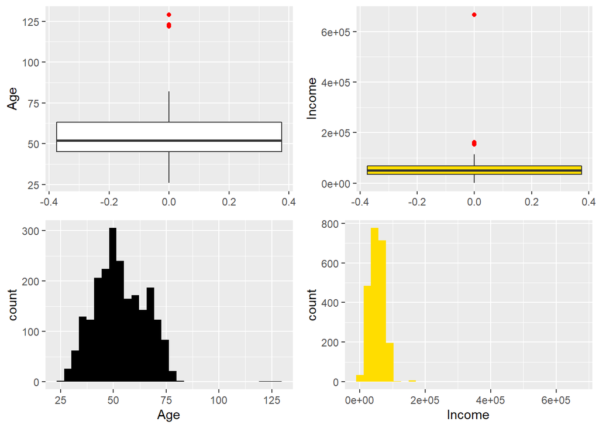

```r
# identify the outliers
g1=ggplot(customers_unfilter, aes(y = Age)) + geom_boxplot(outlier.colour = 'red')
g2=ggplot(customers_unfilter, aes(y = Income)) + geom_boxplot(outlier.colour = 'red',fill='#FFDD00')
g3=ggplot(customers_unfilter, aes(x = Age)) + geom_histogram(fill='black')
g4=ggplot(customers_unfilter, aes(x = Income)) + geom_histogram(fill='#FFDD00')
grid.arrange(g1, g2, g3, g4, ncol=2)
```

```r
# Max Age is > 100
# Dropping outliers by setting a cap on Income and Age
customers <- customers_unfilter %>%
  filter(Income < 600000 & Age < 90)
dim(customers)
```

```
## [1] 2212   30
```

```r
unique(customers$Marital_Status)
```

```
## [1] "Single"   "Together" "Married"  "Divorced" "Widow"    "Alone"    "Absurd"
## [8] "YOLO"
```

## Collapsing Features

Some features have too many unnecessary categories, we can convert to only two categories.

```r
# Collapsing marital Status into two categories: Single & Taken

customers <- customers %>%
  mutate(Marital_Status =
           replace(Marital_Status,
                   Marital_Status == "Divorced" | Marital_Status == "Widow" |
                     Marital_Status == "Alone" | Marital_Status == "Absurd" |
                     Marital_Status == "YOLO",
                   "Single"))
customers <- customers %>%
  mutate(Marital_Status =
           replace(Marital_Status,
                   Marital_Status == "Together" | Marital_Status == "Married",
                   "Taken"))
```

```r
# Collapsing the Education into two Categories: graduate and non-graduate
unique(customers$Education)
```

```
## [1] "Graduation" "PhD"        "Master"     "Basic"      "2n Cycle"
```

```r
customers <- customers %>%
  mutate(Education =
           replace(Education, Education == "Graduation"| Education == "PhD" |
                     Education == "Master" | Education == "2n Cycle",
                   "graduate"))
customers <- customers %>%
  mutate(Education =
           replace(Education, Education == "Basic", "non-graduate"))
```

```r
# Converting them to factors
customers <- customers %>%
  mutate(Marital_Status = as.factor(Marital_Status),
         Education = as.factor(Education))
```

## Renaming Features

```r
# Renaming the Mnt_ features
customers <- customers %>%
  rename(wines = MntWines, fruits = MntFruits, meat = MntMeatProducts,
         fish = MntFishProducts, sweet = MntSweetProducts, gold = MntGoldProds,
         webpurchase = NumWebPurchases, catalog = NumCatalogPurchases,
         Store = NumStorePurchases, webvisit = NumWebVisitsMonth,
         dealpurchase = NumDealsPurchases)
```

```r
# Creating a new variable:Total_spent
customers <- customers %>%
  mutate(Total_spent = wines + fruits + meat + fish + sweet + gold) %>%
  mutate(Total_num = webpurchase + catalog + Store + dealpurchase)
```

```r
# Creating a new variable:kids
customers <- customers %>%
  mutate(Kids = Kidhome + Teenhome)
```

```r
#Dropping some redundant features
customers <- customers %>%
  select(- ID, - Year_Birth, - Dt_Customer, - Z_CostContact,
         - Z_Revenue, - Kidhome, - Teenhome)
str(customers)
```

```
## 'data.frame':    2212 obs. of  26 variables:
##  $ Education     : Factor w/ 2 levels "graduate","non-graduate": 1 1 1 1 1 1 1 1 1 1 ...
##  $ Marital_Status: Factor w/ 2 levels "Single","Taken": 1 1 2 2 2 2 1 2 2 2 ...
##  $ Income        : int  58138 46344 71613 26646 58293 62513 55635 33454 30351 5648 ...
##  $ Recency       : int  58 38 26 26 94 16 34 32 19 68 ...
##  $ wines         : int  635 11 426 11 173 520 235 76 14 28 ...
##  $ fruits        : int  88 1 49 4 43 42 65 10 0 0 ...
##  $ meat          : int  546 6 127 20 118 98 164 56 24 6 ...
##  $ fish          : int  172 2 111 10 46 0 50 3 3 1 ...
##  $ sweet         : int  88 1 21 3 27 42 49 1 3 1 ...
##  $ gold          : int  88 6 42 5 15 14 27 23 2 13 ...
##  $ dealpurchase  : int  3 2 1 2 5 2 4 2 1 1 ...
##  $ webpurchase   : int  8 1 8 2 5 6 7 4 3 1 ...
##  $ catalog       : int  10 1 2 0 3 4 3 0 0 0 ...
##  $ Store         : int  4 2 10 4 6 10 7 4 2 0 ...
##  $ webvisit      : int  7 5 4 6 5 6 6 8 9 20 ...
##  $ AcceptedCmp3  : int  0 0 0 0 0 0 0 0 0 1 ...
##  $ AcceptedCmp4  : int  0 0 0 0 0 0 0 0 0 0 ...
##  $ AcceptedCmp5  : int  0 0 0 0 0 0 0 0 0 0 ...
##  $ AcceptedCmp1  : int  0 0 0 0 0 0 0 0 0 0 ...
##  $ AcceptedCmp2  : int  0 0 0 0 0 0 0 0 0 0 ...
##  $ Complain      : int  0 0 0 0 0 0 0 0 0 0 ...
##  $ Response      : int  1 0 0 0 0 0 0 0 1 0 ...
##  $ Age           : num  65 68 57 38 41 55 51 37 48 72 ...
##  $ Total_spent   : int  1617 27 776 53 422 716 590 169 46 49 ...
##  $ Total_num     : int  25 6 21 8 19 22 21 10 6 2 ...
##  $ Kids          : int  0 2 0 1 1 1 1 1 1 2 ...
##  - attr(*, "na.action")= 'omit' Named int [1:24] 11 28 44 49 59 72 91 92 93 129 ...
##   ..- attr(*, "names")= chr [1:24] "11" "28" "44" "49" ...
```

```r
head(customers, n = 5)
```

```
##   Education Marital_Status Income Recency wines fruits meat fish sweet gold
## 1  graduate         Single  58138      58   635     88  546  172    88   88
## 2  graduate         Single  46344      38    11      1    6    2     1    6
## 3  graduate          Taken  71613      26   426     49  127  111    21   42
## 4  graduate          Taken  26646      26    11      4   20   10     3    5
## 5  graduate          Taken  58293      94   173     43  118   46    27   15
##   dealpurchase webpurchase catalog Store webvisit AcceptedCmp3 AcceptedCmp4
## 1            3           8      10     4        7            0            0
## 2            2           1       1     2        5            0            0
## 3            1           8       2    10        4            0            0
## 4            2           2       0     4        6            0            0
## 5            5           5       3     6        5            0            0
##   AcceptedCmp5 AcceptedCmp1 AcceptedCmp2 Complain Response Age Total_spent
## 1            0            0            0        0        1  65        1617
## 2            0            0            0        0        0  68          27
## 3            0            0            0        0        0  57         776
## 4            0            0            0        0        0  38          53
## 5            0            0            0        0        0  41         422
##   Total_num Kids
## 1        25    0
## 2         6    2
## 3        21    0
## 4         8    1
## 5        19    1
```

# EDA

## 1. Marital Status

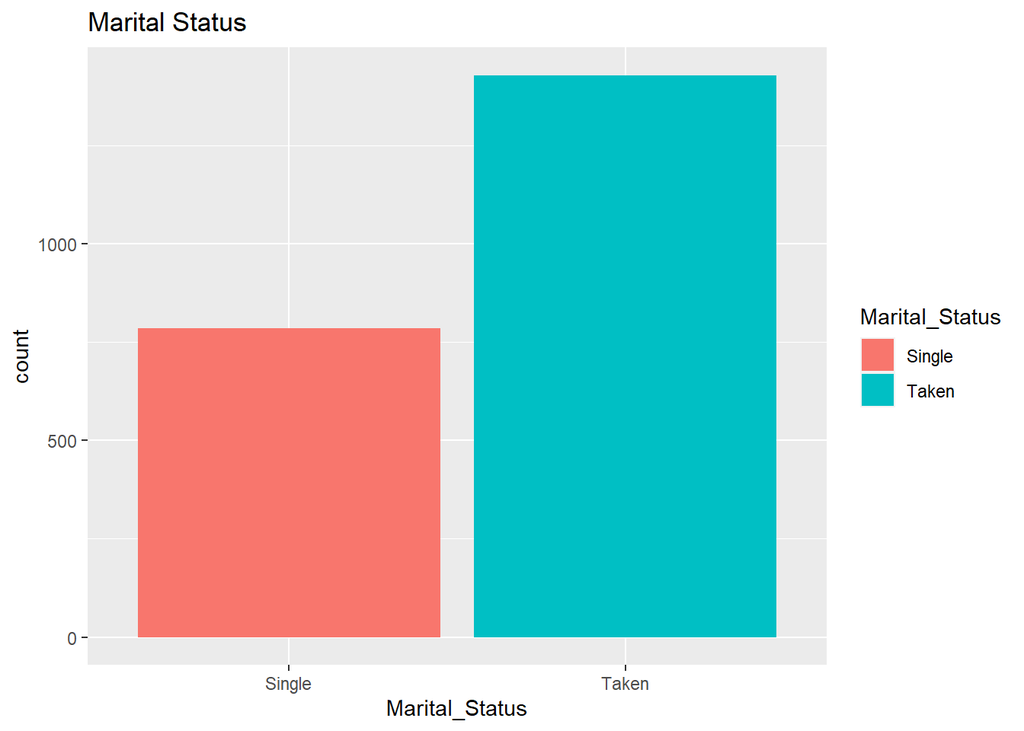

```r
ggplot(customers, aes(x=Marital_Status, fill=Marital_Status)) +
  geom_bar() + ggtitle("Marital Status")
```

```r
g1=ggplot(customers, mapping=aes(x=Education)) +
  geom_bar(fill = "lightblue") + ggtitle("Education Level")
```

## 2. Education

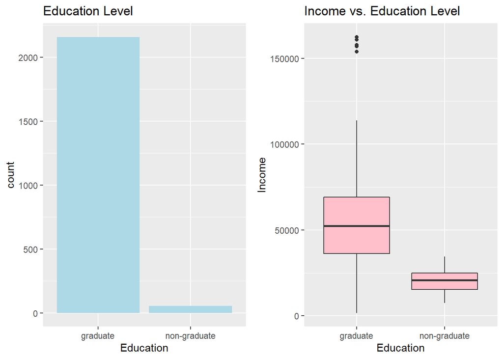

```r
g2=ggplot(customers, aes(x=Education, y=Income)) +
  geom_boxplot(fill = "pink") + ggtitle("Income vs. Education Level")
grid.arrange(g1, g2, ncol=2)
```

## 3. Income

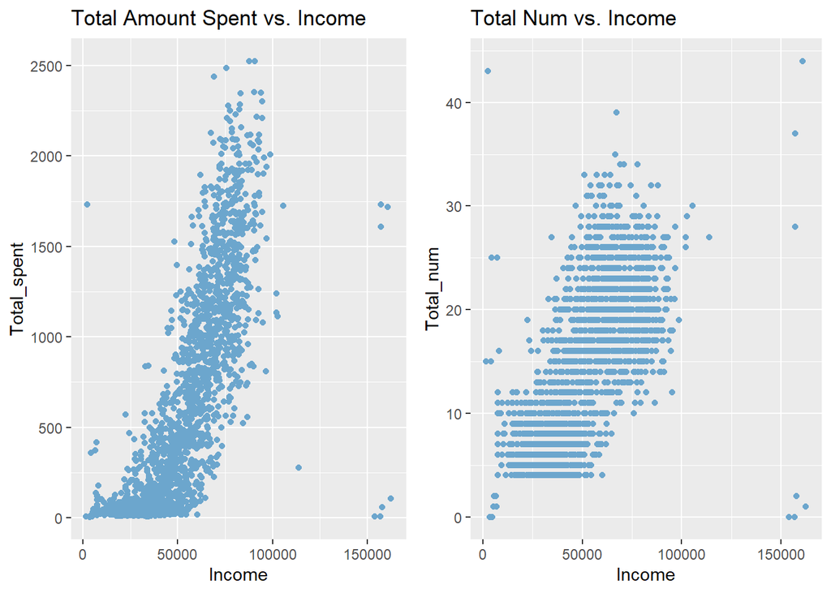

```r
g1=ggplot(customers, aes(x=Income, y=Total_spent)) +
  geom_point(col='Sky Blue 3')+
  scale_x_continuous()+
  ggtitle("Total Amount Spent vs. Income")
g2=ggplot(customers, aes(x=Income, y=Total_num)) +
  geom_point(col='Sky Blue 3')+
  scale_x_continuous()+
  ggtitle("Total Num vs. Income")
grid.arrange(g1, g2, ncol=2)
```

## 4. Products

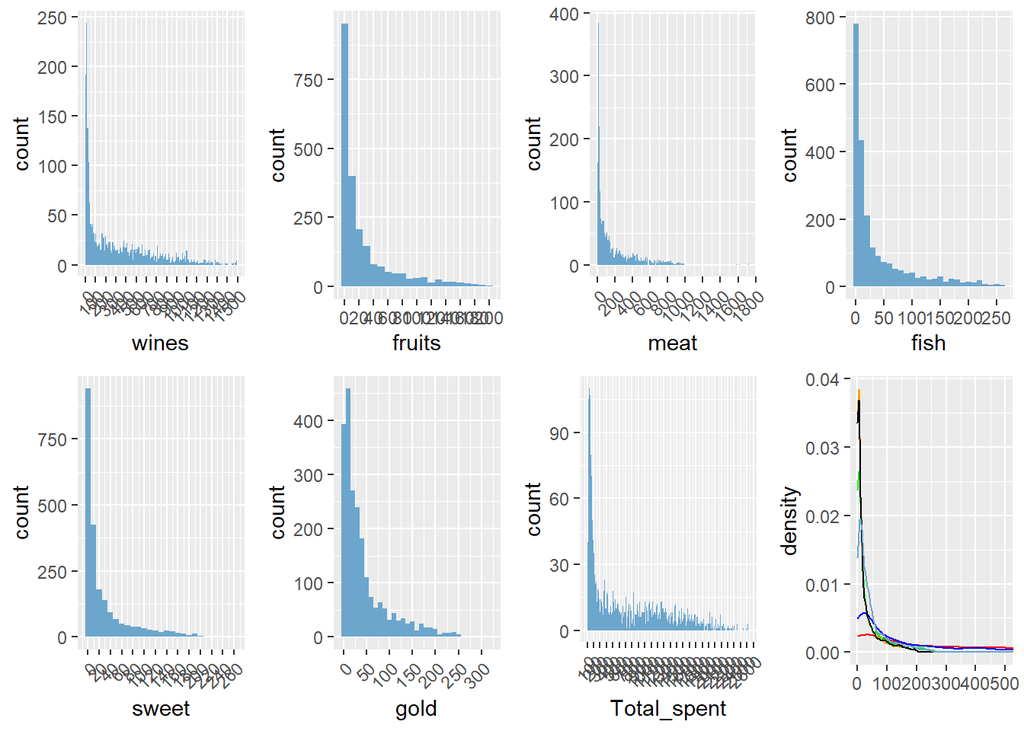

```r
g1 <- ggplot(customers, aes(x = wines)) +
  geom_histogram(fill = "Sky Blue 3", binwidth = 10)+
  scale_x_continuous(breaks = seq(0, 1600, 100)) +
  theme(axis.text.x = element_text(angle=45, vjust=1, hjust=1))
g2 <- ggplot(customers, aes(x = fruits)) +
  geom_histogram(fill = "Sky Blue 3", binwidth = 10)+
  scale_x_continuous(breaks = seq(0, 250, 20))
g3 <- ggplot(customers, aes(x = meat)) +
  geom_histogram(fill = "Sky Blue 3", binwidth = 10)+
  scale_x_continuous(breaks = seq(0, 1800, 200)) +
  theme(axis.text.x = element_text(angle=45, vjust=1, hjust=1))
g4 <- ggplot(customers, aes(x = fish)) +
  geom_histogram(fill = "Sky Blue 3", binwidth = 10)+
  scale_x_continuous(breaks = seq(0, 300, 50))
g5 <- ggplot(customers, aes(x = sweet)) +
  geom_histogram(fill = "Sky Blue 3", binwidth = 10)+
  scale_x_continuous(breaks = seq(0, 300, 20)) +
  theme(axis.text.x = element_text(angle=45, vjust=1, hjust=1))
g6 <- ggplot(customers, aes(x = gold)) +
  geom_histogram(fill = "Sky Blue 3", binwidth = 10)+
  scale_x_continuous(breaks = seq(0, 400, 50)) +
  theme(axis.text.x = element_text(angle=45, vjust=1, hjust=1))
g7 <- ggplot(customers, aes(x = Total_spent)) +
  geom_histogram(fill = "Sky Blue 3", binwidth = 10)+
  scale_x_continuous(breaks = seq(0, 3000, 100)) +
  theme(axis.text.x = element_text(angle=45, vjust=1, hjust=1))
g8 <- ggplot(customers)+
  geom_density(aes(x = wines), color = "Red", fill = 0.7)+
  geom_density(aes(x = fruits), color = "Orange", fill = 0.7)+
  geom_density(aes(x = meat), color = "Blue", fill = 0.7)+
  geom_density(aes(x = fish), color = "Green", fill = 0.7)+
  geom_density(aes(x = sweet), color = "Black", fill = 0.7)+
  geom_density(aes(x = gold), color = "Sky Blue 3", fill = 0.7)+
  coord_cartesian(xlim = c(0, 500))+
  xlab("")

grid.arrange(g1, g2, g3, g4, g5, g6, g7, g8, ncol=4)
```

## 5. Correlation Plot

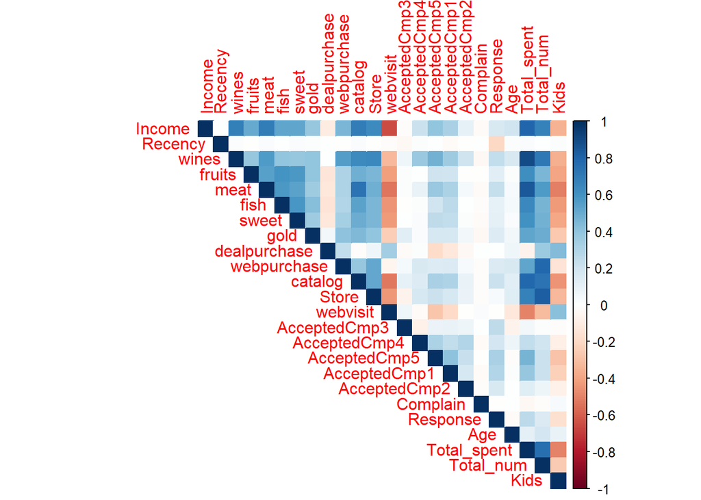

```r
library(corrplot)
#Getting correlation matrix
cust_cor <- cor(customers[,3:26])
corrplot(cust_cor,
         method = "color",
         type = "upper")
```

```r
         # order = "hclust",
         # col = brewer.pal(n=10, name="RdYlBu"))
# png(file="corr.png", res=300, width=4500, height=4500)
# dev.off()
```

## Categorical Data

```r
# Encoding the categorical features to numeric
customers_copy <- customers

customers_copy <- customers_copy %>%
  mutate(Education = case_when(
    Education == "graduate" ~ 1, Education == "non-graduate" ~ 0))
customers_copy <- customers_copy %>%
  mutate(Marital_Status = case_when(
    Marital_Status == "Taken" ~ 1, Marital_Status == "Single" ~ 0))

str(customers_copy$Education)
```

```
##  num [1:2212] 1 1 1 1 1 1 1 1 1 1 ...
```

```r
str(customers_copy$Marital_Status)
```

```
##  num [1:2212] 0 0 1 1 1 1 0 1 1 1 ...
```

```r
dim(customers_copy)
```

```
## [1] 2212   26
```

```r
# glimpse(customers_copy)
```

```r
miss_var_summary(customers_copy)
```

```
## # A tibble: 26 x 3
##    variable       n_miss pct_miss
##    <chr>           <int>    <dbl>
##  1 Education           0        0
##  2 Marital_Status      0        0
##  3 Income              0        0
##  4 Recency             0        0
##  5 wines               0        0
##  6 fruits              0        0
##  7 meat                0        0
##  8 fish                0        0
##  9 sweet               0        0
## 10 gold                0        0
## # ... with 16 more rows
```

# Segmentation

## Pre-processing Data

```r
library(caret)
# preprocessing the data, use numerical data to do dimension reduction
customers_copy_pre <-
  preProcess(customers_copy[,c(3:15, 23:25)], method = c("center", "scale"))

# normalizing
customers_copy <- predict(customers_copy_pre, customers_copy[,c(3:15, 23:25)])
summary(customers_copy)
```

```
##      Income           Recency               wines             fruits
##  Min.   :-2.3333   Min.   :-1.6936473   Min.   :-0.9050   Min.   :-0.6625
##  1st Qu.:-0.7769   1st Qu.:-0.8644347   1st Qu.:-0.8339   1st Qu.:-0.6122
##  Median :-0.0273   Median :-0.0006716   Median :-0.3848   Median :-0.4612
##  Mean   : 0.0000   Mean   : 0.0000000   Mean   : 0.0000   Mean   : 0.0000
##  3rd Qu.: 0.7678   3rd Qu.: 0.8630914   3rd Qu.: 0.5921   3rd Qu.: 0.1678
##  Max.   : 5.1302   Max.   : 1.7268545   Max.   : 3.5210   Max.   : 4.3446
##       meat              fish             sweet              gold
##  Min.   :-0.7448   Min.   :-0.6874   Min.   :-0.6582   Min.   :-0.8495
##  1st Qu.:-0.6735   1st Qu.:-0.6326   1st Qu.:-0.6339   1st Qu.:-0.6755
##  Median :-0.4416   Median :-0.4683   Median :-0.4635   Median :-0.3757
##  Mean   : 0.0000   Mean   : 0.0000   Mean   : 0.0000   Mean   : 0.0000
##  3rd Qu.: 0.2908   3rd Qu.: 0.2255   3rd Qu.: 0.1449   3rd Qu.: 0.2335
##  Max.   : 6.9473   Max.   : 4.0413   Max.   : 5.7179   Max.   : 5.3585
##   dealpurchase      webpurchase          catalog            Store
##  Min.   :-1.2079   Min.   :-1.49084   Min.   :-0.9128   Min.   :-1.7861
##  1st Qu.:-0.6883   1st Qu.:-0.76149   1st Qu.:-0.9128   1st Qu.:-0.8633
##  Median :-0.1687   Median :-0.03215   Median :-0.2296   Median :-0.2481
##  Mean   : 0.0000   Mean   : 0.00000   Mean   : 0.0000   Mean   : 0.0000
##  3rd Qu.: 0.3510   3rd Qu.: 0.69720   3rd Qu.: 0.4535   3rd Qu.: 0.6747
##  Max.   : 6.5863   Max.   : 8.35532   Max.   : 8.6515   Max.   : 2.2127
##     webvisit            Age            Total_spent        Total_num
##  Min.   :-2.1939   Min.   :-2.31476   Min.   :-0.9996   Min.   :-1.94111
##  1st Qu.:-0.9571   1st Qu.:-0.69105   1st Qu.:-0.8934   1st Qu.:-0.89831
##  Median : 0.2798   Median :-0.09284   Median :-0.3490   Median : 0.01414
##  Mean   : 0.0000   Mean   : 0.00000   Mean   : 0.0000   Mean   : 0.00000
##  3rd Qu.: 0.6920   3rd Qu.: 0.84720   3rd Qu.: 0.7315   3rd Qu.: 0.79624
##  Max.   : 6.0515   Max.   : 2.47091   Max.   : 3.1829   Max.   : 3.79431
```

## PCA: Dimensionality Reduction

We use PCA as the segmentation method in this part, it is an unsupervised learning method.

Firstly, we need to standardize some of the features for PCA: Centering and Scaling

We anticipate to have 2 or 3 specific customer groups for the results

```r
#Running a PCA.
customers_copy_pca <- PCA(customers_copy, graph = FALSE)

#Exploring PCA()

# Getting the summary of the pca
summary(customers_copy_pca)
```

```
##
## Call:
## PCA(X = customers_copy, graph = FALSE)
##
##
## Eigenvalues
##                        Dim.1   Dim.2   Dim.3   Dim.4   Dim.5   Dim.6   Dim.7
## Variance               7.434   1.829   1.079   1.000   0.827   0.673   0.639
## % of var.             46.465  11.431   6.741   6.252   5.168   4.205   3.993
## Cumulative % of var.  46.465  57.896  64.637  70.889  76.056  80.261  84.254
##                        Dim.8   Dim.9  Dim.10  Dim.11  Dim.12  Dim.13  Dim.14
## Variance               0.575   0.436   0.399   0.377   0.292   0.256   0.184
## % of var.              3.592   2.728   2.493   2.359   1.828   1.597   1.149
## Cumulative % of var.  87.846  90.574  93.067  95.426  97.254  98.851 100.000
##                       Dim.15  Dim.16
## Variance               0.000   0.000
## % of var.              0.000   0.000
## Cumulative % of var. 100.000 100.000
##
## Individuals (the 10 first)
##                  Dist    Dim.1    ctr   cos2    Dim.2    ctr   cos2    Dim.3
## 1            |  5.491 |  4.272  0.111  0.605 |  0.396  0.004  0.005 |  0.697
## 2            |  3.189 | -2.539  0.039  0.634 | -0.654  0.011  0.042 | -1.422
## 3            |  3.020 |  1.883  0.022  0.389 |  0.182  0.001  0.004 | -0.150
## 4            |  3.136 | -2.742  0.046  0.764 | -0.568  0.008  0.033 |  0.979
## 5            |  2.597 |  0.085  0.000  0.001 |  0.715  0.013  0.076 |  0.714
## 6            |  2.554 |  1.091  0.007  0.183 |  0.891  0.020  0.122 | -0.201
## 7            |  2.124 |  0.883  0.005  0.173 |  0.972  0.023  0.210 |  0.843
## 8            |  2.854 | -2.347  0.033  0.676 |  0.136  0.000  0.002 |  1.290
## 9            |  3.552 | -3.145  0.060  0.784 | -0.267  0.002  0.006 |  0.585
## 10           |  7.523 | -4.849  0.143  0.415 |  1.338  0.044  0.032 |  0.240
##                 ctr   cos2
## 1             0.020  0.016 |
## 2             0.085  0.199 |
## 3             0.001  0.002 |
## 4             0.040  0.097 |
## 5             0.021  0.076 |
## 6             0.002  0.006 |
## 7             0.030  0.158 |
## 8             0.070  0.204 |
```

[output cut: 11 more lines]

```
## sweet        |  0.683  6.274  0.466 | -0.230  2.891  0.053 |  0.229  4.859
## gold         |  0.580  4.529  0.337 |  0.126  0.869  0.016 |  0.254  5.972
## dealpurchase | -0.030  0.012  0.001 |  0.794 34.508  0.631 |  0.164  2.500
## webpurchase  |  0.606  4.942  0.367 |  0.560 17.128  0.313 |  0.083  0.634
##                cos2
## Income        0.051 |
## Recency       0.032 |
## wines         0.021 |
## fruits        0.071 |
## meat          0.000 |
## fish          0.050 |
## sweet         0.052 |
## gold          0.064 |
## dealpurchase  0.027 |
## webpurchase   0.007 |
```

```r
#Getting the variance of the first 8 new dimensions
customers_copy_pca$eig[,2][1:8]
```

```
##    comp 1    comp 2    comp 3    comp 4    comp 5    comp 6    comp 7    comp 8
## 46.464788 11.431160  6.741227  6.251565  5.167577  4.204525  3.992843  3.592394
```

```r
#Getting the cummulative variance
customers_copy_pca$eig[,3][1:8]
```

```
##   comp 1   comp 2   comp 3   comp 4   comp 5   comp 6   comp 7   comp 8
## 46.46479 57.89595 64.63717 70.88874 76.05632 80.26084 84.25368 87.84608
```

```r
#Tracing variable contributions in customers_pca
customers_copy_pca$var$contrib
```

```
##                     Dim.1        Dim.2        Dim.3        Dim.4        Dim.5
## Income        9.795757924  0.495384008 4.749615e+00 2.948303e-01  2.214556314
## Recency       0.004579413  0.008693595 2.986338e+00 9.633489e+01  0.002858636
## wines         8.487984211  2.268563515 1.980708e+00 6.861465e-02 10.333163167
## fruits        6.236085347  3.513309806 6.567481e+00 2.095683e-02  9.944335904
## meat          8.706831579  2.988581730 7.649743e-03 4.109597e-02  4.915749537
## fish          6.673976602  3.858364653 4.624684e+00 4.701107e-02 10.669902888
## sweet         6.273728695  2.891186359 4.858516e+00 3.424587e-01  8.051085971
## gold          4.528624178  0.869438785 5.972192e+00 5.726921e-01 14.739096490
## dealpurchase  0.011781204 34.508008842 2.500131e+00 3.646655e-01  0.115970224
## webpurchase   4.941673488 17.127570714 6.340136e-01 1.421811e-02  0.551695066
## catalog       9.213729804  0.075283716 4.555626e-01 1.764697e-02  3.066526464
## Store         8.045872720  2.183760872 2.410467e-01 1.793061e-01  0.548661958
## webvisit      4.804018733 14.473495324 7.659895e+00 2.513166e-01  0.245821064
## Age           0.365799504  2.647375878 5.671471e+01 1.445942e+00 31.651862827
## Total_spent  12.126992089  0.019137688 9.480278e-04 3.958298e-03  2.550285584
## Total_num     9.782564508 12.071844516 4.650595e-02 3.952069e-04  0.398427908
```

### Visualizing PCA

#### 1. Eigenvalues/variances vs. the Number of Dimensions

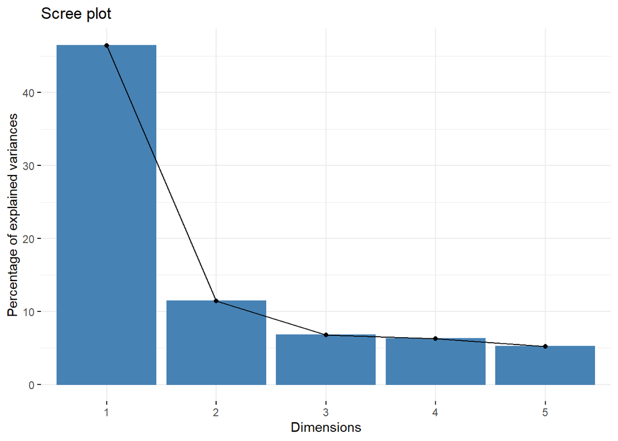

```r
# Plot the eigenvalues/variances against the number of dimensions
fviz_screeplot(customers_copy_pca, ncp=5)
```

In this plot, we could find that the first principal component will explain about 46% variance, second principal component is about 11% and the third principal component is about 6%. Thus, we will use first two principal component to do the following analysis.

#### 2. Variable Contributions

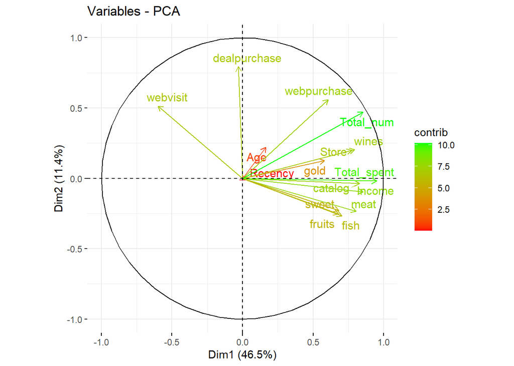

```r
#Creating a factor map for the variable contributions
fviz_pca_var(customers_copy_pca,
             col.circle = 'black',
             col.var = "contrib",
             gradient.cols = c("red", "green"),
             repel = TRUE)
```

#### 3. Top 5 Variable Contributions

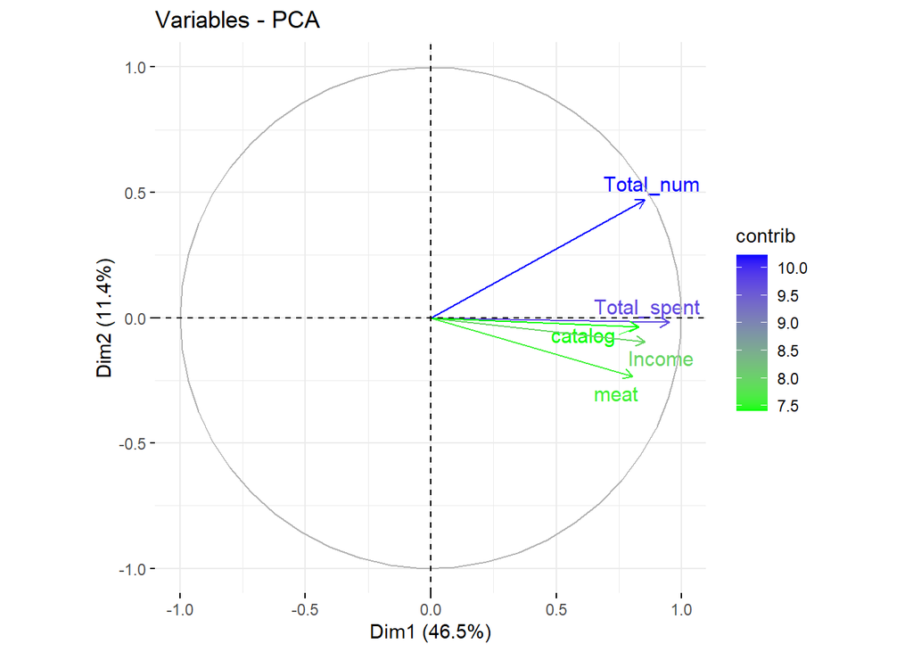

```r
#Creating a factor map for the top 5 variables with the highest contributions.
fviz_pca_var(customers_copy_pca,
             select.var = list(contrib = 5),
             col.var = "contrib",
             gradient.cols = c("green", "blue"),
             repel = TRUE)
```

#### 4. Top 5 Variable Contributions in Barplot

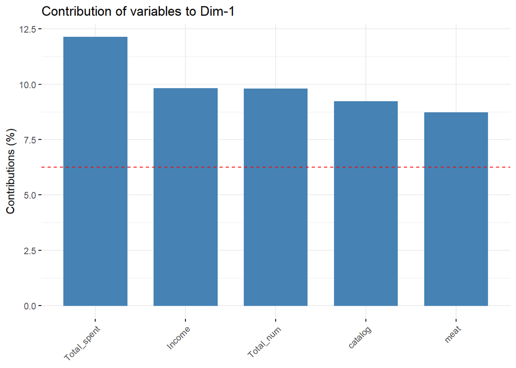

```r
fviz_contrib(customers_copy_pca, choice = "var", axes = 1, top = 5)
```

#### 5. Graph of Individuals

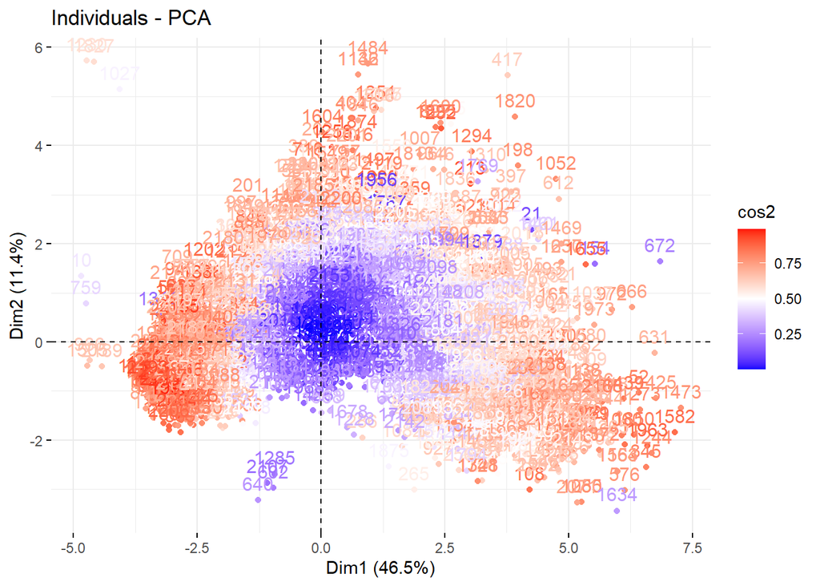

```r
fviz_pca_ind(customers_copy_pca, col.ind="cos2") +
  scale_color_gradient2(low="blue", mid="white",high="red", midpoint=0.50)
```

#### 6. Biplot

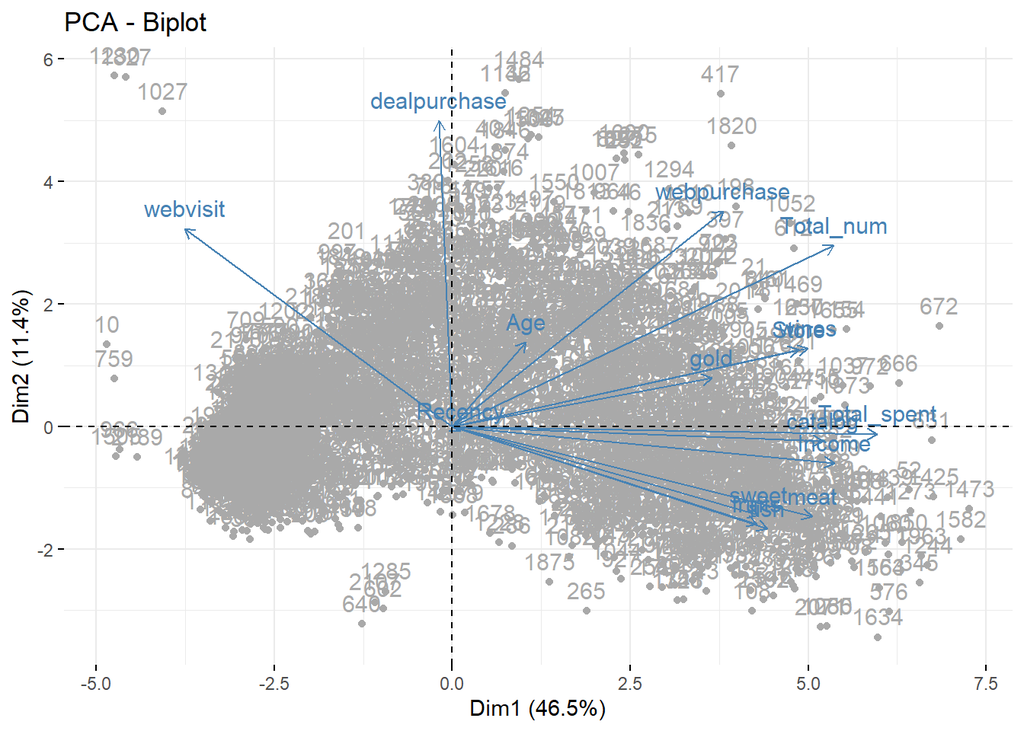

```r
fviz_pca_biplot(customers_copy_pca, col.ind = 'dark grey')
```

#### 7. Hierarchical Cluster

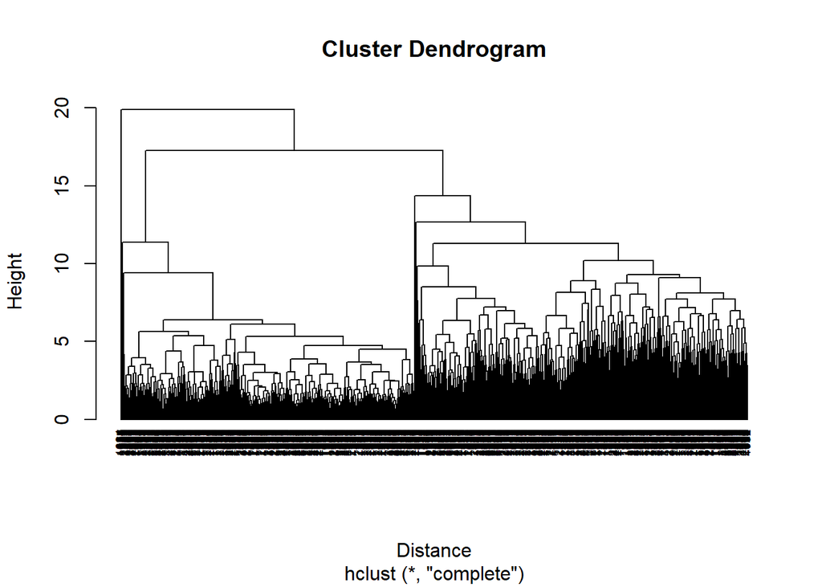

```r
Distance <- dist(customers_copy, method = 'euclidean')
hplot<-hclust(Distance, method='complete')
plot(hplot, hang = -1, cex = 0.6)
```

## K-Means Clustering

```r
#The elbow method to find cluster number with kmean method
library(purrr)
tot_withinss <- map_dbl(1:10, function(k){
  model <- kmeans(x = customers_copy, centers = k)
  model$tot.withinss
})

elbow_df <- data.frame(
       k = 1:10,
       tot_withinss = tot_withinss)
head(elbow_df)
```

```
##   k tot_withinss
## 1 1     35376.00
## 2 2     22250.00
## 3 3     19112.24
## 4 4     18304.32
## 5 5     17287.71
## 6 6     16515.84
```

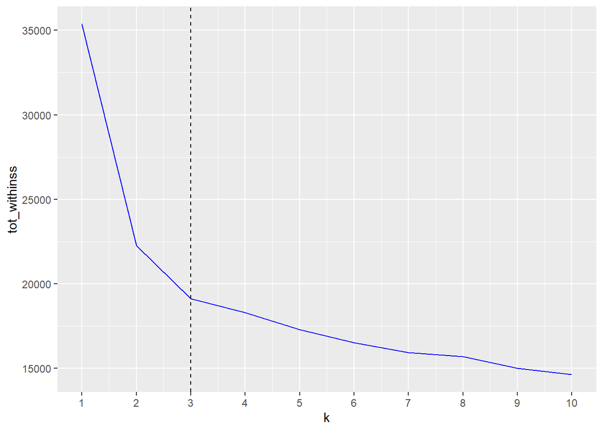

```r
#plotting the elbow plot
ggplot(elbow_df, aes(k, tot_withinss)) +
  geom_line(col='blue') +
  scale_x_continuous(breaks = 1:10)+
  geom_vline(xintercept=3,linetype=2)
```

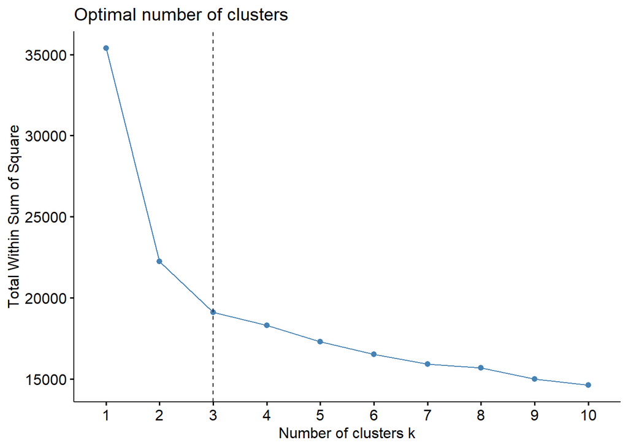

```r
#plot elbow with package function
fviz_nbclust(customers_copy,kmeans,method="wss")+
  geom_vline(xintercept=3,linetype=2)
```

We can see that two way of the scree plot methods will plot the same result. And we will choose three as the cluster number.

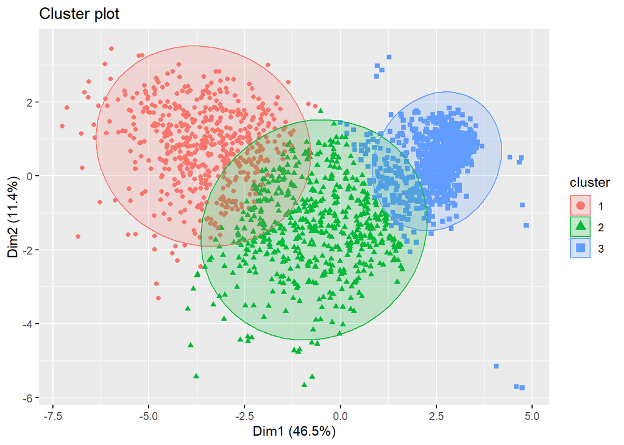

```r
set.seed(1313)
res_kmeans <- kmeans(customers_copy, centers = 3, nstart = 10)
# autoplot(res_kmeans, data=customers_copy)
fviz_cluster(res_kmeans,
             customers_copy,
             geom = "point",
             ellipse.type = "norm",
             repel = TRUE)
```

```r
set.seed(3)

#Building a k-means model with a k of 2
customers_md <- kmeans(customers_copy, center = 3)

#Extracting the vector of cluster assignment from the model
clust_customers <- as.factor(customers_md$cluster)

#Building the segment_customers dataframe
segment_customers <- mutate(customers_copy, cluster = clust_customers)

#Calculating the mean for each category
count(segment_customers, cluster)
```

```
##   cluster    n
## 1       1 1013
## 2       2  605
## 3       3  594
```

```r
#Adding the cluster variable to the original dataframe
customers <- customers %>% mutate(cluster = segment_customers$cluster)
head(customers, n = 3)
```

```
##   Education Marital_Status Income Recency wines fruits meat fish sweet gold
## 1  graduate         Single  58138      58   635     88  546  172    88   88
## 2  graduate         Single  46344      38    11      1    6    2     1    6
## 3  graduate          Taken  71613      26   426     49  127  111    21   42
##   dealpurchase webpurchase catalog Store webvisit AcceptedCmp3 AcceptedCmp4
## 1            3           8      10     4        7            0            0
## 2            2           1       1     2        5            0            0
## 3            1           8       2    10        4            0            0
##   AcceptedCmp5 AcceptedCmp1 AcceptedCmp2 Complain Response Age Total_spent
## 1            0            0            0        0        1  65        1617
## 2            0            0            0        0        0  68          27
## 3            0            0            0        0        0  57         776
##   Total_num Kids cluster
## 1        25    0       3
## 2         6    2       1
## 3        21    0       2
```

```r
#confirming
count(customers, cluster)
```

```
##   cluster    n
## 1       1 1013
## 2       2  605
## 3       3  594
```

### Segmenting Results

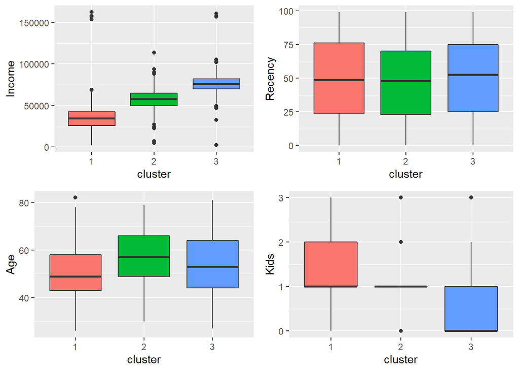

```r
g1=ggplot(data = customers, aes(x = cluster, y = Income, fill = cluster))+
  geom_boxplot() +
  theme(legend.position = "none")

g2=ggplot(data = customers, aes(x = cluster, y = Recency, fill = cluster))+
  geom_boxplot() +
  theme(legend.position = "none")

g111=ggplot(data = customers, aes(x = cluster, y = Age, fill = cluster))+
  geom_boxplot() +
  theme(legend.position = "none")

g112=ggplot(data = customers, aes(x = cluster, y = Kids, fill = cluster))+
  geom_boxplot() +
  theme(legend.position = "none")

g3=ggplot(data = customers, aes(x = cluster, y = wines, fill = cluster))+
  geom_boxplot() +
  theme(legend.position = "none")

g4=ggplot(data = customers, aes(x = cluster, y = fruits, fill = cluster))+
  geom_boxplot() +
  theme(legend.position = "none")

g5=ggplot(data = customers, aes(x = cluster, y = meat, fill = cluster))+
  geom_boxplot() +
  theme(legend.position = "none")

g6=ggplot(data = customers, aes(x = cluster, y = fish, fill = cluster))+
  geom_boxplot() +
  theme(legend.position = "none")

g7=ggplot(data = customers, aes(x = cluster, y = sweet, fill = cluster))+
  geom_boxplot() +
  theme(legend.position = "none")

g8=ggplot(data = customers, aes(x = cluster, y = gold, fill = cluster))+
  geom_boxplot() +
  theme(legend.position = "none")

g9=ggplot(data = customers, aes(x = cluster, y = dealpurchase, fill = cluster))+
  geom_boxplot() +
  theme(legend.position = "none")

g10=ggplot(data = customers, aes(x = cluster, y = webpurchase, fill = cluster))+
  geom_boxplot() +
  theme(legend.position = "none")

g11=ggplot(data = customers, aes(x = cluster, y = catalog, fill = cluster))+
  geom_boxplot() +
  theme(legend.position = "none")

g12=ggplot(data = customers, aes(x = cluster, y = Store, fill = cluster))+
  geom_boxplot() +
  theme(legend.position = "none")

g13=ggplot(data = customers, aes(x = cluster, y = Total_num, fill = cluster))+
  geom_boxplot() +
  theme(legend.position = "none")

grid.arrange(g1, g2, g111, g112, ncol=2)
```

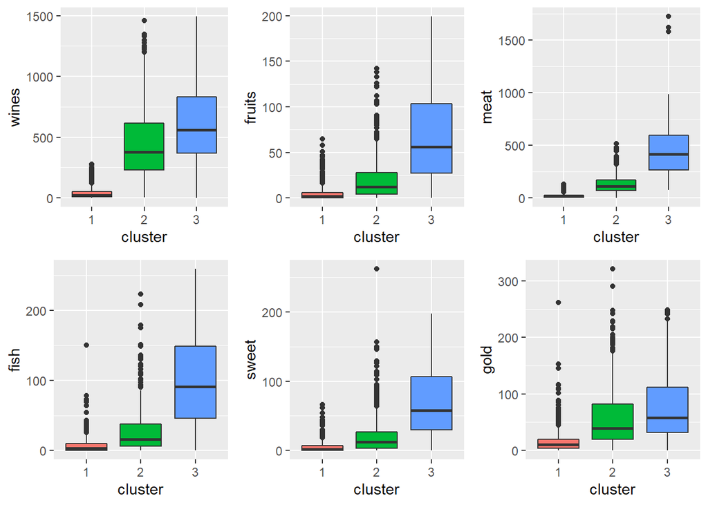

```r
grid.arrange(g3, g4, g5, g6, g7, g8, ncol=3)
```

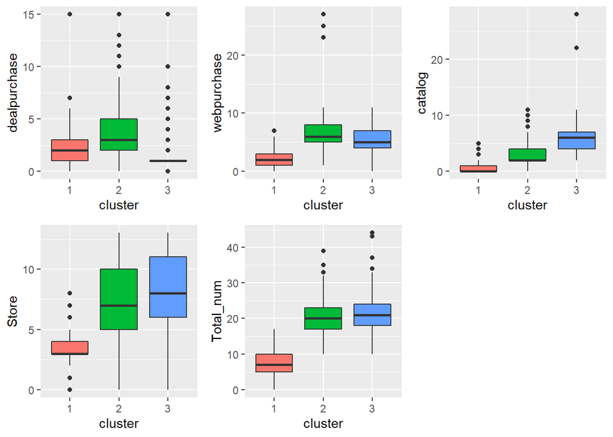

```r
grid.arrange(g9, g10, g11, g12, g13, ncol=3)
```

# Conclusion

Basically, from the k-means clustering, we can separate customers into three groups with the following characteristics:

Cluster 1:

Low purchasing power customer

No wine/meat

have more kids

Cluster 2:

Median purchasing power customer

prefer deal/web, but have some level of purchasing potential

Cluster 3:

High purchasing power customer

Prefer catalog/store

Purchasing more product

# Future steps

We will explore factor analysis which is one of the most populare analysis technique in market analysis